# Electricity Cost Of Oregon Households: Multivariate Regression Analysis

Oluwatomi Hassan

2022-05-19

# Exploratory Data Analysis

```r
# Reading the Dataset
df <- read.csv('./data/OR_acs_house_occ.csv')
summary(df)
```

```
##     SERIALNO             NP              TYPE       ACR
##  Min.   :     70   Min.   : 1.000   Min.   :1   Length:15166
##  1st Qu.: 368628   1st Qu.: 1.000   1st Qu.:1   Class :character
##  Median : 748326   Median : 2.000   Median :1   Mode  :character
##  Mean   : 749620   Mean   : 2.403   Mean   :1
##  3rd Qu.:1126788   3rd Qu.: 3.000   3rd Qu.:1
##  Max.   :1513284   Max.   :13.000   Max.   :1
##
##       BDSP           BLD                 ELEP            FULP
##  Min.   :0.000   Length:15166       Min.   :  4.0   Min.   :   1.00
##  1st Qu.:2.000   Class :character   1st Qu.: 70.0   1st Qu.:   2.00
##  Median :3.000   Mode  :character   Median :100.0   Median :   2.00
##  Mean   :2.789                      Mean   :116.2   Mean   :  85.25
##  3rd Qu.:3.000                      3rd Qu.:150.0   3rd Qu.:   2.00
##  Max.   :7.000                      Max.   :540.0   Max.   :2500.00
##
##       GASP            HFL                 RMSP           TEN
##  Min.   :  3.00   Length:15166       Min.   : 1.00   Length:15166
##  1st Qu.:  3.00   Class :character   1st Qu.: 4.00   Class :character
##  Median :  3.00   Mode  :character   Median : 6.00   Mode  :character
##  Mean   : 35.68                      Mean   : 6.01
##  3rd Qu.: 50.00                      3rd Qu.: 7.00
##  Max.   :350.00                      Max.   :16.00
##
##       VALP             YBL                R18                R60
##  Min.   :   1000   Length:15166       Length:15166       Length:15166
##  1st Qu.: 160000   Class :character   Class :character   Class :character
##  Median : 250000   Mode  :character   Mode  :character   Mode  :character
##  Mean   : 301966
##  3rd Qu.: 360000
##  Max.   :2476000
##  NA's   :4632
```

```r
# Checking for missing values
sum(is.na(df))
```

```
## [1] 7218
```

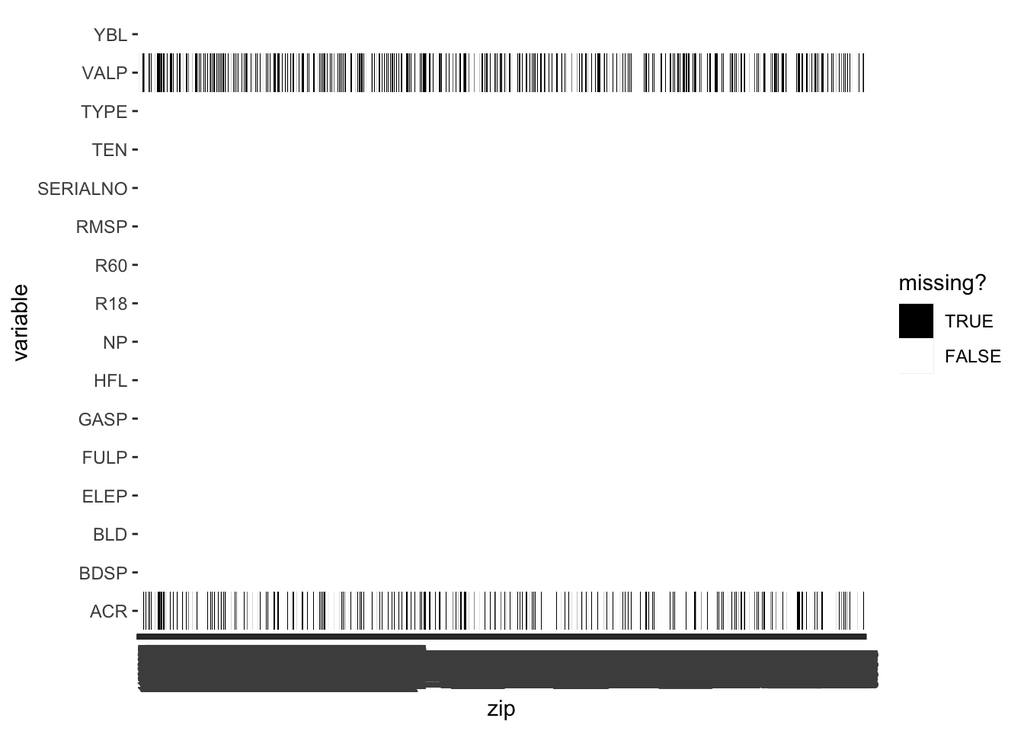

```r
df$zip <- rownames(df)
df_long <- gather(df, variable, value, -zip)

qplot(zip, variable, data = df_long, geom= "tile",
      fill = is.na(value)) +
  scale_fill_manual("missing?" , values = c('TRUE'="black", 'FALSE' = "white")) +
  theme (axis.text.x = element_text(angle=90))
```

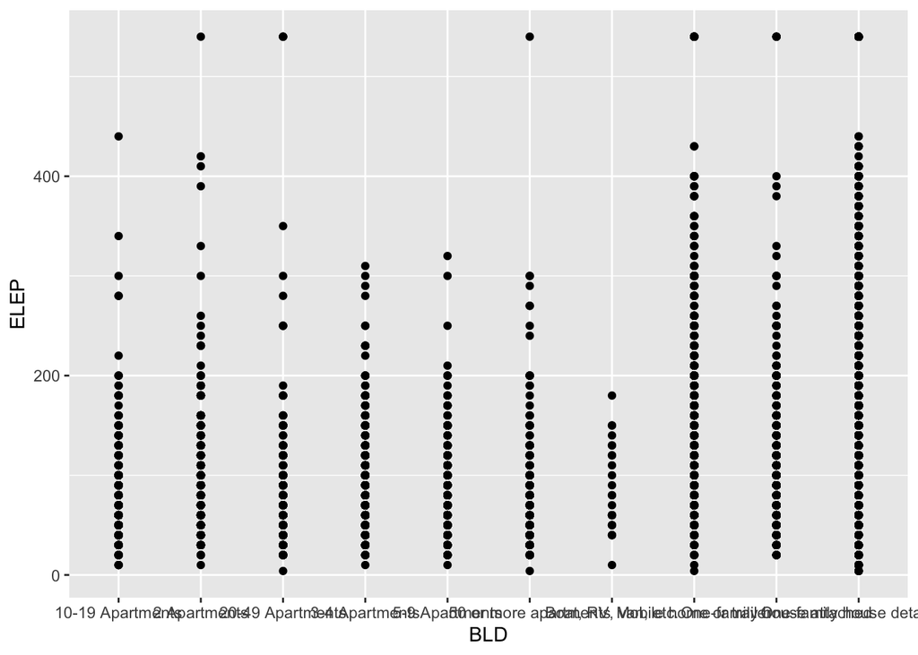

```r
# Exploratory Data Analysis
qplot(BLD, ELEP, data=df)
```

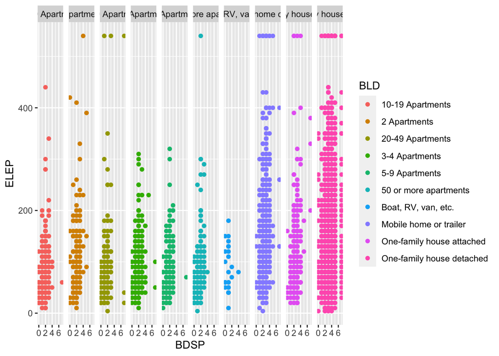

```r
qplot(BDSP, ELEP, data=df, color = BLD) + facet_wrap(~ BLD, ncol=10)
```

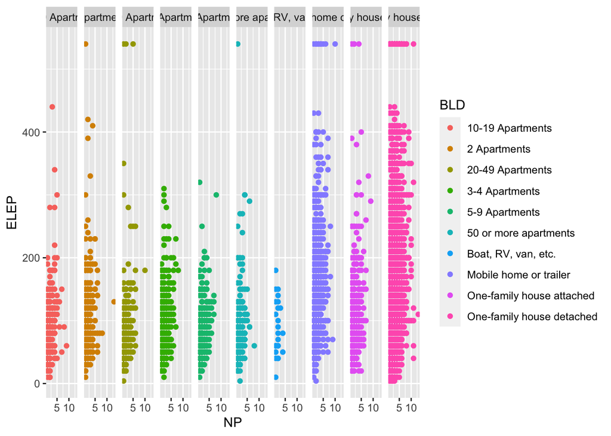

```r
qplot(NP, ELEP, data=df, color = BLD) + facet_wrap(~BLD, ncol=10)
```

# Multiple Regression Explanatory Model

## Methodology

The following regression models are considered to estimate the difference in monthly electricity bill between apartment and houses in Oregon. Let BLD =0 when housing is an apartment and BLD=1 when housing is a house, full model with interactions $(ELEP|BLD,BDSP,NP) = \beta_0 + \beta_1{BLD} + \beta_2{BDSP} + \beta_3{NP} + \beta_4{(BLD * NP)} + \beta_5{(BLD * BDSP)} + \beta_6{(BLD * BDSP * NP)}$ is compared to the reduced model without interactions terms $(ELEP|BLD,BDSP,NP) = \beta_0 + \beta_1{BLD} + \beta_2{BDSP} + \beta_3{NP}$. The comparison of the full model to the reduced model suggest that the full model is the more appropriate model(Extra SS F-test, p-value=0.0008967). Insignificant interaction terms and three-variable interaction terms are removed from the model to decrease noise and over-fitting. The model $\mu(ELEP|BLD,BDSP,NP) = \beta_0 + \beta_1{BLD} + \beta_2{BDSP} + \beta_3{NP} + \beta_4{(BDSP * NP)} + \beta_5{(BLD * BDSP)}$ is considered after model training. AIC and BIC values comparison of this proposed model to the reduced model without interaction terms suggest that the reduced model is the more appropriate model for this study.

```r
# Cleaning the dataframe
df$HA <- "other" # Initialize everything to "other"
df$HA[which(grepl("house",df$BLD))] <- "house"
df$HA[which(grepl("apartment",df$BLD,ignore.case=TRUE))] <- "apt"

new_df <- subset(df, HA!="other" )
head(new_df)
```

```
##   SERIALNO NP TYPE                         ACR BDSP                       BLD
## 1       70  4    1 House on less than one acre    2 One-family house detached
## 2      163  2    1 House on less than one acre    2 One-family house detached
## 3      178  1    1 House on less than one acre    3 One-family house detached
## 4      243  2    1 House on less than one acre    4 One-family house detached
## 6      603  3    1 House on less than one acre    3 One-family house detached
## 7      743  2    1 House on less than one acre    3 One-family house detached
##   ELEP FULP GASP                      HFL RMSP                         TEN
## 1   70    2    3                     Wood    4                      Rented
## 2  100  600    3 Fuel oil, kerosene, etc.    7 Owned with mortgage or loan
## 3   60    2  110              Utility gas    8        Owned free and clear
## 4   80    2   20              Utility gas    8        Owned free and clear
## 6  200    2   20              Electricity    7 Owned with mortgage or loan
## 7  120    2    3              Electricity    4        Owned free and clear
##     VALP             YBL       R18       R60 zip    HA
## 1     NA 1939 or earlier 1 or more      none   1 house
## 2 225000 1939 or earlier      none      none   2 house
## 3 315000 1939 or earlier      none 1 or more   3 house
## 4 200000    1950 to 1959      none 1 or more   4 house
## 6  90000 1939 or earlier 1 or more      none   6 house
## 7 200000    1960 to 1969      none      none   7 house
```

```r
 # fitting rich model with interactions
exp_fit_int <- lm(ELEP ~ HA * BDSP * NP ,  data= new_df )
summary(exp_fit_int)
```

```
##
## Call:
## lm(formula = ELEP ~ HA * BDSP * NP, data = new_df)
##
## Residuals:
##     Min      1Q  Median      3Q     Max
## -187.57  -44.31  -14.54   25.23  465.47
##
## Coefficients:
##                 Estimate Std. Error t value Pr(>|t|)
## (Intercept)       24.192      5.496   4.402 1.08e-05 ***
## HAhouse           32.600      7.151   4.559 5.20e-06 ***
## BDSP              20.848      2.791   7.468 8.60e-14 ***
## NP                18.715      2.939   6.367 1.98e-10 ***
## HAhouse:BDSP      -9.970      3.139  -3.176 0.001495 **
## HAhouse:NP        -5.013      3.369  -1.488 0.136722
## BDSP:NP           -3.972      1.134  -3.503 0.000461 ***
## HAhouse:BDSP:NP    3.591      1.226   2.929 0.003402 **
## ---
## Signif. codes:  0 '***' 0.001 '**' 0.01 '*' 0.05 '.' 0.1 ' ' 1
##
## Residual standard error: 69.62 on 13766 degrees of freedom
## Multiple R-squared:  0.1249, Adjusted R-squared:  0.1245
## F-statistic: 280.8 on 7 and 13766 DF,  p-value: < 2.2e-16
```

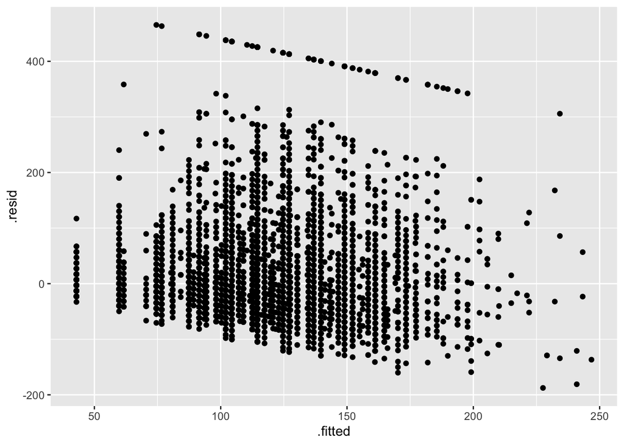

```r
# Residual Plots for full model with interactions.
exp_fit_aug <- broom::augment(exp_fit_int, data = new_df)
qplot(.fitted, .resid, data = exp_fit_aug)
```

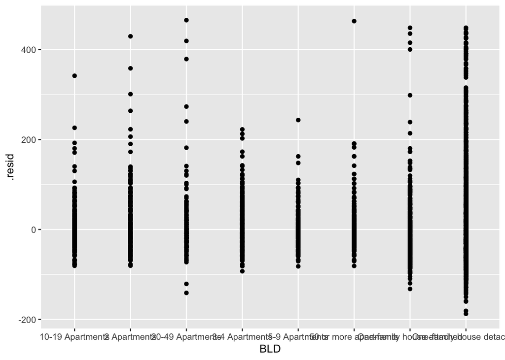

```r
qplot(BLD, .resid, data =exp_fit_aug)
```

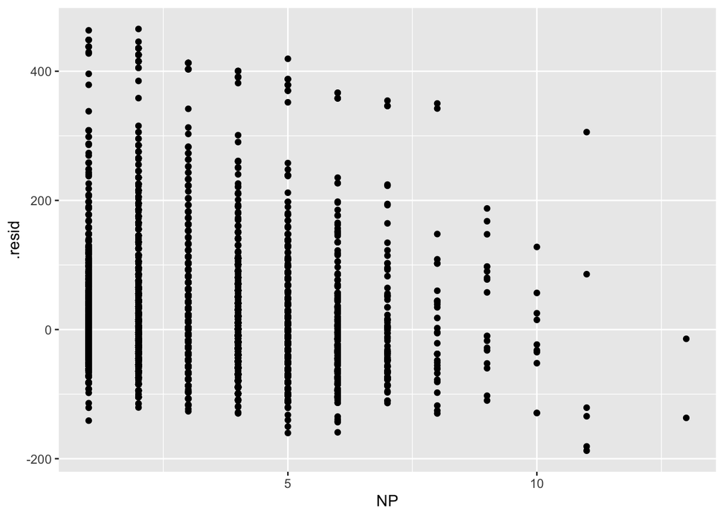

```r
qplot(NP, .resid, data =exp_fit_aug)
```

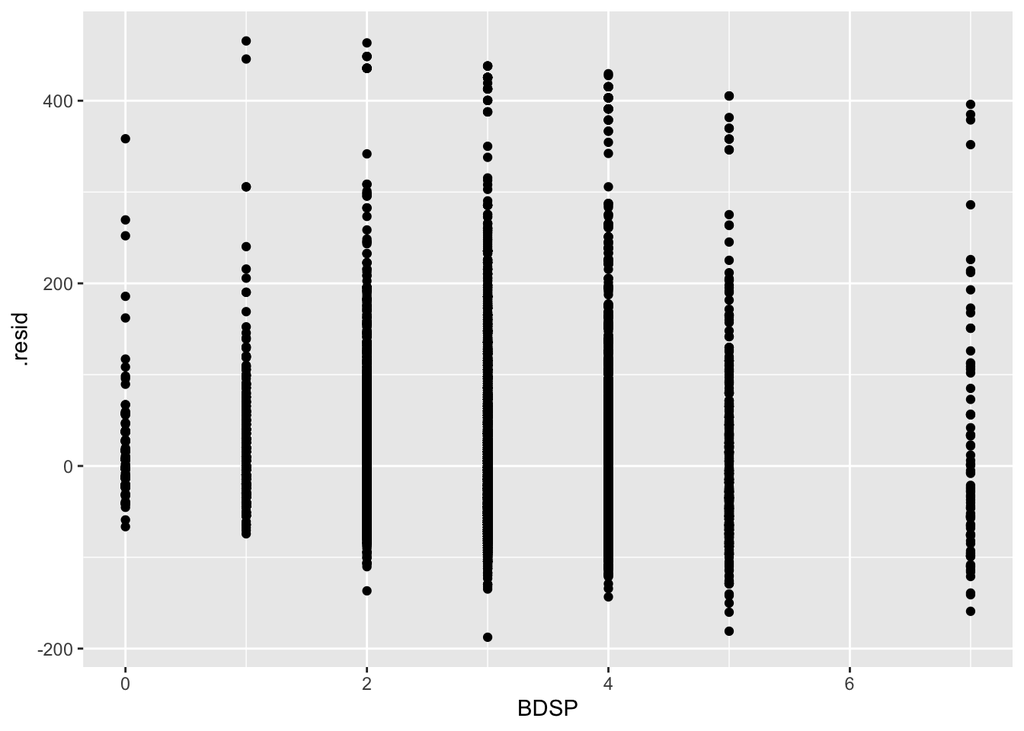

```r
qplot(BDSP, .resid, data =exp_fit_aug)
```

```r
# Fitting Model without interactions
exp_fit<- lm(ELEP ~ HA + BDSP + NP ,  data= new_df )
summary(exp_fit)
```

```
##
## Call:
## lm(formula = ELEP ~ HA + BDSP + NP, data = new_df)
##
## Residuals:
##     Min      1Q  Median      3Q     Max
## -183.70  -42.98  -14.64   25.13  467.23
##
## Coefficients:
##             Estimate Std. Error t value Pr(>|t|)
## (Intercept)  39.9979     1.8687   21.40   <2e-16 ***
## HAhouse      19.4731     1.7932   10.86   <2e-16 ***
## BDSP         10.3674     0.7214   14.37   <2e-16 ***
## NP           12.0356     0.4683   25.70   <2e-16 ***
## ---
## Signif. codes:  0 '***' 0.001 '**' 0.01 '*' 0.05 '.' 0.1 ' ' 1
##
## Residual standard error: 69.66 on 13770 degrees of freedom
## Multiple R-squared:  0.1238, Adjusted R-squared:  0.1236
## F-statistic: 648.2 on 3 and 13770 DF,  p-value: < 2.2e-16
```

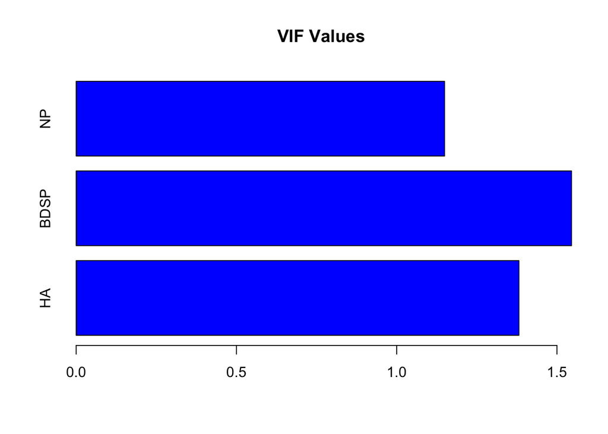

```r
# checkinfg for multicollinearity
corr <- vif(exp_fit)
barplot(corr, main = "VIF Values", horiz= TRUE, col = "blue")
abline(v=5, lwd=3, lty=2)
```

```r
# Comparing model with and without interactions
anova(exp_fit, exp_fit_int)
```

```
## Analysis of Variance Table
##
## Model 1: ELEP ~ HA + BDSP + NP
## Model 2: ELEP ~ HA * BDSP * NP
##   Res.Df      RSS Df Sum of Sq    F    Pr(>F)
## 1  13770 66813068
## 2  13766 66722335  4     90733 4.68 0.0008967 ***
## ---
## Signif. codes:  0 '***' 0.001 '**' 0.01 '*' 0.05 '.' 0.1 ' ' 1
```

```r
# Fitting regression model with some interactions
exp_fit_2 <- lm(ELEP ~ HA + BDSP * NP + HA:BDSP , data= new_df )
summary(exp_fit_2)
```

```
##
## Call:
## lm(formula = ELEP ~ HA + BDSP * NP + HA:BDSP, data = new_df)
##
## Residuals:
##     Min      1Q  Median      3Q     Max
## -183.97  -43.65  -14.81   24.76  467.25
##
## Coefficients:
##              Estimate Std. Error t value Pr(>|t|)
## (Intercept)   35.0291     3.6922   9.487  < 2e-16 ***
## HAhouse       20.9916     4.2202   4.974 6.64e-07 ***
## BDSP          12.5276     1.7828   7.027 2.21e-12 ***
## NP            13.7411     1.4029   9.795  < 2e-16 ***
## BDSP:NP       -0.5373     0.4102  -1.310    0.190
## HAhouse:BDSP  -1.0188     1.9377  -0.526    0.599
## ---
## Signif. codes:  0 '***' 0.001 '**' 0.01 '*' 0.05 '.' 0.1 ' ' 1
##
## Residual standard error: 69.66 on 13768 degrees of freedom
## Multiple R-squared:  0.1239, Adjusted R-squared:  0.1236
## F-statistic: 389.5 on 5 and 13768 DF,  p-value: < 2.2e-16
```

```r
# comparing model without interaction and considered model above.
anova(exp_fit, exp_fit_2)
```

```
## Analysis of Variance Table
##
## Model 1: ELEP ~ HA + BDSP + NP
## Model 2: ELEP ~ HA + BDSP * NP + HA:BDSP
##   Res.Df      RSS Df Sum of Sq     F Pr(>F)
## 1  13770 66813068
## 2  13768 66800123  2     12945 1.334 0.2634
```

```r
AIC(exp_fit, exp_fit_2)
```

```
##           df      AIC
## exp_fit    5 155997.1
## exp_fit_2  7 155998.4
```

```r
BIC(exp_fit, exp_fit_2)
```

```
##           df      BIC
## exp_fit    5 156034.7
## exp_fit_2  7 156051.1
```

```r
# Extracting estimates and CI of model without interactions.
summary(exp_fit)$coefficients
```

```
##             Estimate Std. Error  t value      Pr(>|t|)
## (Intercept) 39.99788  1.8686695 21.40447 5.134693e-100
## HAhouse     19.47313  1.7932360 10.85921  2.327360e-27
## BDSP        10.36737  0.7213878 14.37143  1.696103e-46
## NP          12.03562  0.4683361 25.69868 2.664254e-142
```

```r
confint(exp_fit)
```

```
##                 2.5 %   97.5 %
## (Intercept) 36.335033 43.66073
## HAhouse     15.958141 22.98812
## BDSP         8.953356 11.78139
## NP          11.117616 12.95362
```

Using the American Community survey for household survey, Multiple linear regression was used to extrapolate the average difference in monthly electricity bill for people in apartment when compared to those in houses in Oregon. The fitted regression model is: Let BLD =0 when housing is an apartment and BLD=1 when housing is a house $\mu(ELEP|BLD,BDSP,NP) = \beta_0 + \beta_1{BLD} + \beta_2{BDSP} + \beta_3{NP}$. It was estimated that people in apartments receive an average monthly electricity bill of 19.5 dollars less than those in houses in Oregon after accounting for number of occupants and bedrooms. With 95% confidence, the average difference in monthly electricity bill for apartments and houses with fixed number of occupants and bedrooms is between 15.96 and 22.99 dollars, respectively.